# Case Study 3 - Patterns in DNA

Paul Samra, Brian Whiteaker, Rajat Shah, Janis Corona, Henry Qiu

02/26/2015

**Some quick notes on using rMarkdown. will be removed later on**

*ctrl + i* to insert a “chunk” of code

*ctrl + alt + c* to run a “chunk” of code

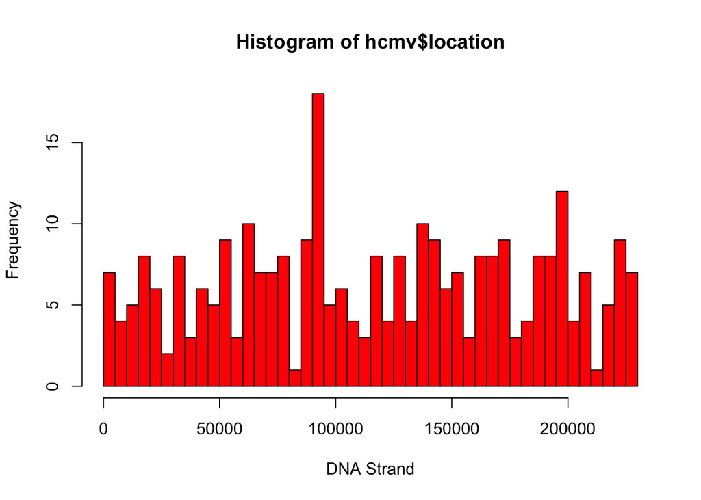

```r
hcmv = read.table(file="http://www.stat.berkeley.edu/users/statlabs/data/hcmv.data", header=T)

hist(hcmv$location, breaks=50, xlab = "DNA Strand", col = "red")
```

```r
test = 4;
```

- [Random scatter] To begin, pursue the point of view that structure in the data is indicated by departures from a uniform scatter of palindromes across the DNA. ** Of course, a random uniform scatter, does not mean that the palindromes will be equally spaced as milestones on a freeway. There will be some gaps on the DNA where no palindromes occur, and there will be some clumping together of palindromes. To look for structure examine the locations of the palindromes, the spacing between palindromes, and the counts of palindromes in non overlapping regions of the DNA. One starting place might be to see first how random scatter looks by using a computer to simulate it. ** A computer can simulate 296 palindrome sites chosen at random along a DNA sequence of 229,354 bases using a pseudo random number generator. When this is done several times,by making seller sets of simulated palindrome locations, then the real data can be compared to the simulated data.
- [Locations and spacings] Use graphical methods to examine the spacings between consecutive palindromes and sum of consecutive pairs, triplets, etc, spacings. Compare what you find to what would you expect to find in a random scatter. Also, use graphical methods to compare locations of the palindromes.

*[Counts] Use graphical methods and more formal statistical tests to examine the counts of palindromes in various regions of the DNA. Split the DNA into nonoverlaping regions of equal length to compare the number of palindromes in an interval to the number of that would you expect from uniform random scatter. The counts for shorter regions will be more variable than those for longer regions. Also consider classifying the regions according to their number of counts.

- [The biggest cluster] Does the interval with the greatest number of palindromes indicate a potential origin of replication?Be careful in making your intervals, for any small, but significant ,deviations from random scatter, such as a tight cluster of a few palindromes, could easily go undetected if the regions examined are too large. Also, if the regions are too small, a cluster of palindromes may be split between adjacent intervals and not appear as a high-count interval.

How would you advise biologist who is a bout to start experimentally searching for the origin of replication? Write your recommendations in the form of a report that a team members including biologist will read.